# Survival

## Used libraries. Please, check the versions of your libraries

```r
require(survival)
require(knitr)
require(ggplot2)
require(survminer)
require(coin)
```

In this work we will analise with Ovarian Cancer Survival Dataset - data about survival in a randomised trial comparing two treatments for ovarian cancer. Data was taken from this research: [Edmonson JH, Fleming TR, Decker DG, Malkasian GD, Jorgensen EO, Jefferies JA, Webb MJ, Kvols LK. Different chemotherapeutic sensitivities and host factors affecting prognosis in advanced ovarian carcinoma versus minimal residual disease. Cancer Treat Rep. 1979 Feb;63(2):241-7. PMID: 445503](https://pubmed.ncbi.nlm.nih.gov/445503/)

Variables in the data:  
**futime**: survival or censoring time  
**fustat**: censoring status  
**age**: in years  
**resid.ds**: residual disease present (1=no,2=yes)  
**rx**: treatment group  
**ecog.ps**: ECOG performance status (1 is better)

## 1. EDA

### Structure of the data

```r
data <- ovarian
str(data)
```

```
## 'data.frame':    26 obs. of  6 variables:
##  $ futime  : num  59 115 156 421 431 448 464 475 477 563 ...
##  $ fustat  : num  1 1 1 0 1 0 1 1 0 1 ...
##  $ age     : num  72.3 74.5 66.5 53.4 50.3 ...
##  $ resid.ds: num  2 2 2 2 2 1 2 2 2 1 ...
##  $ rx      : num  1 1 1 2 1 1 2 2 1 2 ...
##  $ ecog.ps : num  1 1 2 1 1 2 2 2 1 2 ...
```

Variables **fustat**, **resid.ds**, **rx** and **ecog.ps** should be factors:

```r
#data$fustat <- factor(data$fustat, labels  = c(0, 1))
#data$resid.ds <- factor(data$resid.ds, labels  = c(0, 1))
#data$rx <- factor(data$rx)
#data$ecog.ps <- factor(data$ecog.ps)
#str(data)
```

We have `26` of observation. We have no missing values:

```r
kable(colSums(is.na(data)), col.names = c("NA"))
```

|  | NA |
| --- | --- |
| futime | 0 |
| fustat | 0 |
| age | 0 |
| resid.ds | 0 |
| rx | 0 |
| ecog.ps | 0 |

Now let’e take a look at simply summary of the data. Here the most interesting variables are **futime** and **age**:

```r
summary(data)
```

```
##      futime           fustat            age           resid.ds
##  Min.   :  59.0   Min.   :0.0000   Min.   :38.89   Min.   :1.000
##  1st Qu.: 368.0   1st Qu.:0.0000   1st Qu.:50.17   1st Qu.:1.000
##  Median : 476.0   Median :0.0000   Median :56.85   Median :2.000
##  Mean   : 599.5   Mean   :0.4615   Mean   :56.17   Mean   :1.577
##  3rd Qu.: 794.8   3rd Qu.:1.0000   3rd Qu.:62.38   3rd Qu.:2.000
##  Max.   :1227.0   Max.   :1.0000   Max.   :74.50   Max.   :2.000
##        rx         ecog.ps
##  Min.   :1.0   Min.   :1.000
##  1st Qu.:1.0   1st Qu.:1.000
##  Median :1.5   Median :1.000
##  Mean   :1.5   Mean   :1.462
##  3rd Qu.:2.0   3rd Qu.:2.000
##  Max.   :2.0   Max.   :2.000
```

## 2. Kaplan–Meier plot

```r
km <- Surv(data$futime, data$fustat)
km
```

```
##  [1]   59   115   156   421+  431   448+  464   475   477+  563   638   744+
## [13]  769+  770+  803+  855+ 1040+ 1106+ 1129+ 1206+ 1227+  268   329   353
## [25]  365   377+
```

```r
km_fit <- survfit(Surv(futime, fustat) ~ 1, data = data)
summary(km_fit)
```

```
## Call: survfit(formula = Surv(futime, fustat) ~ 1, data = data)
##
##  time n.risk n.event survival std.err lower 95% CI upper 95% CI
##    59     26       1    0.962  0.0377        0.890        1.000
##   115     25       1    0.923  0.0523        0.826        1.000
##   156     24       1    0.885  0.0627        0.770        1.000
##   268     23       1    0.846  0.0708        0.718        0.997
##   329     22       1    0.808  0.0773        0.670        0.974
##   353     21       1    0.769  0.0826        0.623        0.949
##   365     20       1    0.731  0.0870        0.579        0.923
##   431     17       1    0.688  0.0919        0.529        0.894
##   464     15       1    0.642  0.0965        0.478        0.862
##   475     14       1    0.596  0.0999        0.429        0.828
##   563     12       1    0.546  0.1032        0.377        0.791
##   638     11       1    0.497  0.1051        0.328        0.752
```

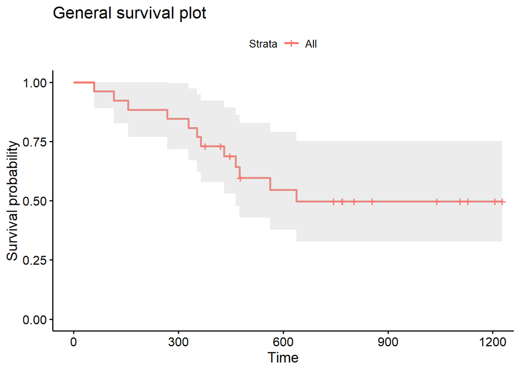

```r
ggsurvplot(km_fit, data = data, conf.int = TRUE, title = "General survival plot")
```

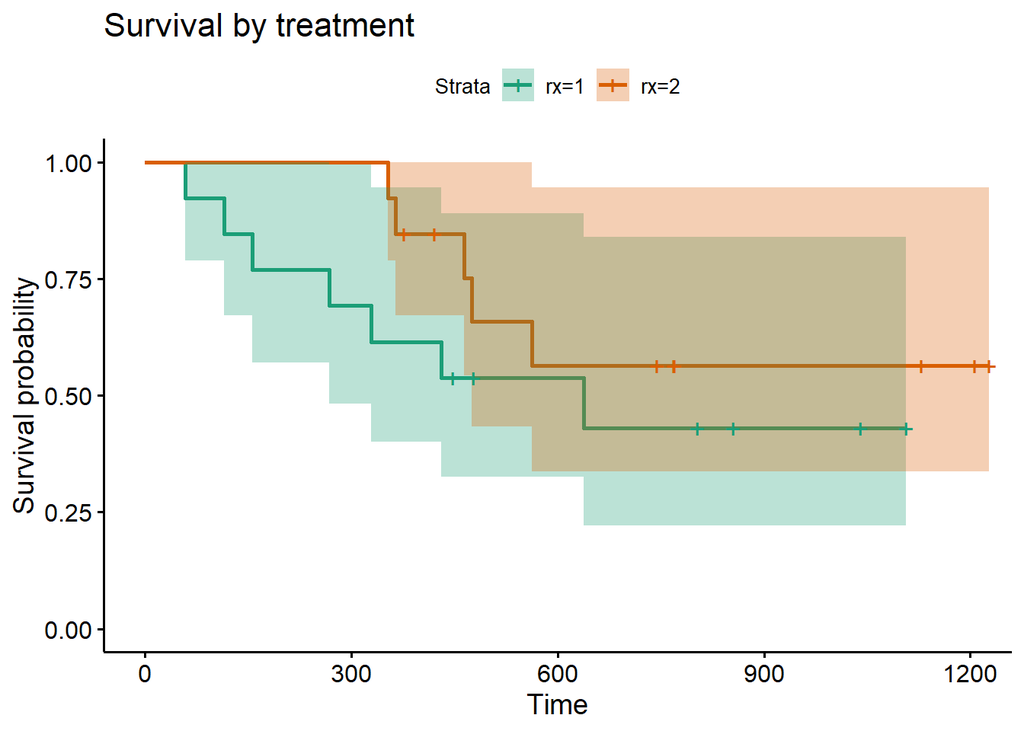

```r
km_trt_fit <- survfit(Surv(futime, fustat) ~ rx, data=data)
ggsurvplot(km_trt_fit, data = data, conf.int = TRUE, title = "Survival by treatment",
           palette = 'Dark2')
```

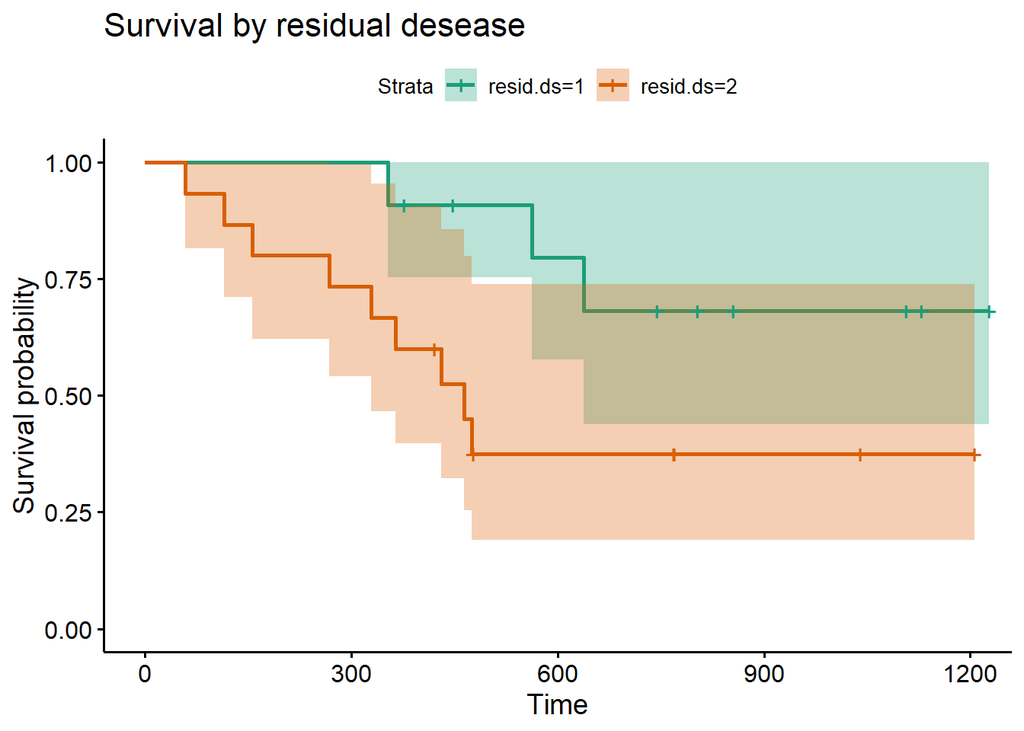

```r
km_res_fit <- survfit(Surv(futime, fustat) ~ resid.ds, data=data)
ggsurvplot(km_res_fit, data = data, conf.int = TRUE, title = "Survival by residual desease",
           palette = 'Dark2')
```

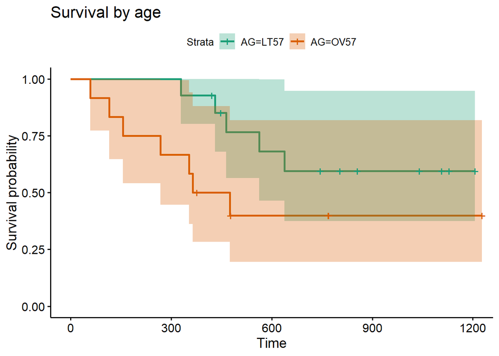

```r
data <- mutate(data, AG = ifelse((age < 57), "LT57", "OV57"))

km_AG_fit <- survfit(Surv(futime, fustat) ~ AG, data = data)
ggsurvplot(km_AG_fit, data = data, conf.int = TRUE, title = "Survival by age",
           palette = 'Dark2')
```

We can see, that survival is higher in patients with alternative treatment, without residual desease and younger that 57 y.o.

## 3. Log-rank tests

Estimate if the difference in survival between groups:

```r
logrank_test(Surv(futime, fustat) ~ as.factor(rx), data = data)
```

```
##
##  Asymptotic Two-Sample Logrank Test
##
## data:  Surv(futime, fustat) by as.factor(rx) (1, 2)
## Z = -1.0296, p-value = 0.3032
## alternative hypothesis: true theta is not equal to 1
```

```r
logrank_test(Surv(futime, fustat) ~ as.factor(resid.ds), data = data)
```

```
##
##  Asymptotic Two-Sample Logrank Test
##
## data:  Surv(futime, fustat) by as.factor(resid.ds) (1, 2)
## Z = 1.9234, p-value = 0.05444
## alternative hypothesis: true theta is not equal to 1
```

```r
logrank_test(Surv(futime, fustat) ~ as.factor(ecog.ps), data = data)
```

```
##
##  Asymptotic Two-Sample Logrank Test
##
## data:  Surv(futime, fustat) by as.factor(ecog.ps) (1, 2)
## Z = 0.69106, p-value = 0.4895
## alternative hypothesis: true theta is not equal to 1
```

```r
logrank_test(Surv(futime, fustat) ~ as.factor(AG), data = data)
```

```
##
##  Asymptotic Two-Sample Logrank Test
##
## data:  Surv(futime, fustat) by as.factor(AG) (LT57, OV57)
## Z = 1.5717, p-value = 0.116
## alternative hypothesis: true theta is not equal to 1
```

These test show us, that there is no difference.

## 4. Analysis of factors influencing risk (Cox model)

```r
cox <- coxph(Surv(futime, fustat) ~ rx + resid.ds + ecog.ps + age, data = data)
summary(cox)
```

```
## Call:
## coxph(formula = Surv(futime, fustat) ~ rx + resid.ds + ecog.ps +
##     age, data = data)
##
##   n= 26, number of events= 12
##
##              coef exp(coef) se(coef)      z Pr(>|z|)
## rx       -0.91450   0.40072  0.65332 -1.400  0.16158
## resid.ds  0.82619   2.28459  0.78961  1.046  0.29541
## ecog.ps   0.33621   1.39964  0.64392  0.522  0.60158
## age       0.12481   1.13294  0.04689  2.662  0.00777 **
## ---
## Signif. codes:  0 '***' 0.001 '**' 0.01 '*' 0.05 '.' 0.1 ' ' 1
##
##          exp(coef) exp(-coef) lower .95 upper .95
## rx          0.4007     2.4955    0.1114     1.442
## resid.ds    2.2846     0.4377    0.4861    10.738
## ecog.ps     1.3996     0.7145    0.3962     4.945
## age         1.1329     0.8827    1.0335     1.242
##
## Concordance= 0.807  (se = 0.068 )
## Likelihood ratio test= 17.04  on 4 df,   p=0.002
## Wald test            = 14.25  on 4 df,   p=0.007
## Score (logrank) test = 20.81  on 4 df,   p=3e-04
```

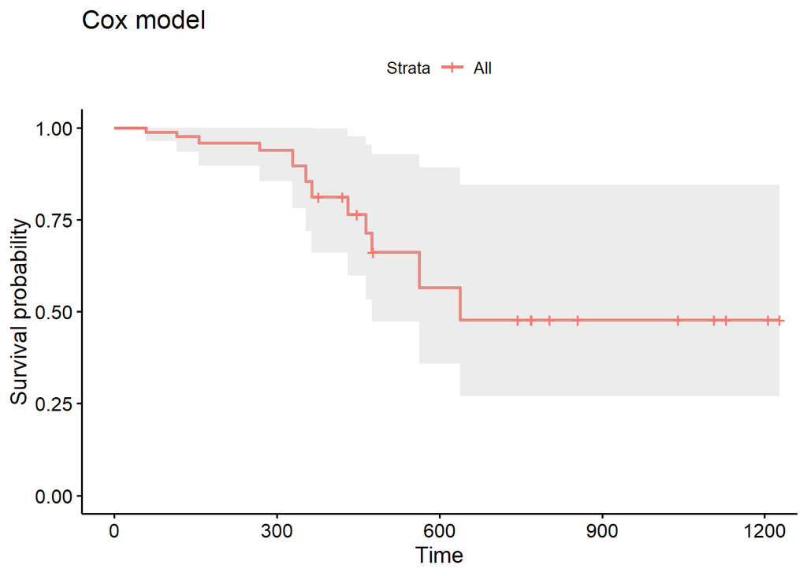

```r
cox_fit <- survfit(cox)
ggsurvplot(cox_fit, data = data, conf.int = TRUE, title = "Cox model")
```

We can see, that the only factor that really affects survival is age.

```r
aa_fit <- aareg(Surv(futime, fustat) ~ rx + resid.ds + ecog.ps + age, data = data)
# autoplot(aa_fit, data = data)
```

Hazard Ratio:

```r
fit.coxph <- coxph(Surv(futime, fustat) ~ as.factor(rx) + as.factor(resid.ds) + as.factor(ecog.ps) + age, data = data)
summary(fit.coxph)
```

```
## Call:
## coxph(formula = Surv(futime, fustat) ~ as.factor(rx) + as.factor(resid.ds) +
##     as.factor(ecog.ps) + age, data = data)
##
##   n= 26, number of events= 12
##
##                          coef exp(coef) se(coef)      z Pr(>|z|)
## as.factor(rx)2       -0.91450   0.40072  0.65332 -1.400  0.16158
## as.factor(resid.ds)2  0.82619   2.28459  0.78961  1.046  0.29541
## as.factor(ecog.ps)2   0.33621   1.39964  0.64392  0.522  0.60158
## age                   0.12481   1.13294  0.04689  2.662  0.00777 **
## ---
## Signif. codes:  0 '***' 0.001 '**' 0.01 '*' 0.05 '.' 0.1 ' ' 1
##
##                      exp(coef) exp(-coef) lower .95 upper .95
## as.factor(rx)2          0.4007     2.4955    0.1114     1.442
## as.factor(resid.ds)2    2.2846     0.4377    0.4861    10.738
## as.factor(ecog.ps)2     1.3996     0.7145    0.3962     4.945
## age                     1.1329     0.8827    1.0335     1.242
##
## Concordance= 0.807  (se = 0.068 )
## Likelihood ratio test= 17.04  on 4 df,   p=0.002
## Wald test            = 14.25  on 4 df,   p=0.007
## Score (logrank) test = 20.81  on 4 df,   p=3e-04
```

```r
# ggforest(fit.coxph, data = data) # didn't work, I don't understand why
```